# BinMat: Processes Binary Data Obtained from Fragment Analysis

Clarke van Steenderen

2020-02-14

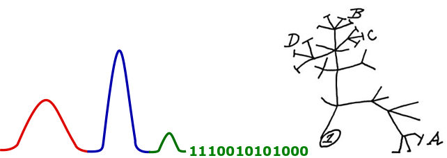

*Department of Zoology and Entomology*

*The Centre for Biological Control* (https://www.ru.ac.za/centreforbiologicalcontrol/)

*Rhodes University, Grahamstown, Eastern Cape, South Africa*

*e-mail:* vsteenderen@gmail.com

The idea behind this package was taken from Clarke’s M.Sc. thesis entitled  
“*A genetic analysis of the species and intraspecific lineages of* Dactylopius *Costa (Hemiptera:Dactylopiidae)*”  
(doi = [10.13140/RG.2.2.28470.86083](https://www.researchgate.net/publication/339124038_A_genetic_analysis_of_the_species_and_intraspecific_lineages_of_Dactylopius_Costa_Hemiptera_Dactylopiidae)). The GUI version of this package is available on the [R Shiny online server](https://clarkevansteenderen.shinyapps.io/BINMAT/), or it is accessible via GitHub by typing:  
shiny::runGitHub(“BinMat”, “CJMvS”)  
into the console in R.

## **OVERVIEW**

Processing and visualising trends in the binary data obtained from fragment analysis methods in molecular biology can be a time-consuming and cumbersome process, and typically entails complex workflows. The BinMat package automates the analysis pipeline on one platform, and was written to process binary matrices derived from dominant marker genetic analyses. The program consolidates replicate sample pairs in a dataset into consensus reads, produces summary statistics (peaks and error rates), and allows the user to visualise their data as non-metric multidimensional scaling (nMDS) plots and hierarchical clustering trees.

## **UPLOADING DATA**

**Data type 1**

Binary data containing replicate pairs that need be consolidated should be in the following example format, uploaded as CSV file (use the read.csv() function):

|  | Locus 1 | Locus 2 | Locus 3 | Locus 4 | Locus 5 |
| --- | --- | --- | --- | --- | --- |
| Sample A replicate 1 | 0 | 0 | 1 | 1 | 1 |
| Sample A replicate 2 | 0 | 0 | 1 | 1 | 1 |
| Sample B replicate 1 | 1 | 1 | 0 | 0 | 0 |
| Sample B replicate 2 | 0 | 1 | 0 | 0 | 1 |

Note that replicate pairs must be directly underneath each other, and that each sample needs to have a unique name.

The following conditions are applied to binary data replicates:

1. A 0 and a 1 produces a “?”
2. A 0 and a 0 produces a “0”
3. A 1 and a 1 produces a “1”

The consolidated output for the above example would thus be:

|  | Locus 1 | Locus 2 | Locus 3 | Locus 4 | Locus 5 |
| --- | --- | --- | --- | --- | --- |
| Sample A replicate 1 & 2 | 0 | 0 | 1 | 1 | 1 |
| Sample B replicate 1 & 2 | ? | 1 | 0 | 0 | ? |

**Data type 2**

Binary data that has already been consolidated must have grouping information in the second column, as shown in the example below. This should also be in CSV format. This matrix can be used to create an nMDS plot coloured by group.

|  | Group | Locus 1 | Locus 2 | Locus 3 | Locus 4 | Locus 5 |
| --- | --- | --- | --- | --- | --- | --- |
| Sample A | Africa | ? | 0 | 1 | 1 | 1 |
| Sample B | Asia | 0 | 0 | 1 | 1 | ? |
| Sample C | Europe | 1 | ? | 0 | 0 | 0 |
| Sample D | USA | ? | 1 | 0 | ? | 1 |

## **FUNCTIONS**

[output not shown]

## **METHODS**

**Euclidean error = (f01 + f10) / (f01 + f10 + f00 + f11)**

The Euclidean error rate includes the shared absence of a band (f00).

**Jaccard error = (f01 + f10) / (f01 + f10 + f11)**

The Jaccard error rate does not take shared absences of bands into account. The error rate will thus be inflated compared to the Euclidean.

In the formulae above, ‘f’ refers to the frequency of each combination (i.e. ‘f01 + f10’ means the sum of all the occurences of a zero and a one, and a one and a zero). An error value is calculated for each replicate pair, and an average obtained representing the whole dataset.

The error rates for the example samples below would be:

**Sample X rep 1: 0 1 1 0**

**Sample X rep 2: 1 0 1 0**

Euclidean error = (1+1) / (1+1+1+1) = 2/4 = 0.5

Jaccard error = (1+1) / (1+1+1) = 2/3 = 0.67

**Sample Y rep 1: 1 1 1 0**

**Sample Y rep 2: 1 1 0 0**

Euclidean error = (1) / (1+1+2) = 1/4 = 0.25

Jaccard error = (1) / (1+2) = 1/3 = 0.33

Average Euclidean error = (0.5+0.25) / 2 = 0.38

Average Jaccard error = (0.67+0.33) / 2 = 0.5